# Estadística Descriptiva: tablas y gráficos

Edimer David Jaramillo

20 de febrero de 2018

# Tablas

Las tablas contribuyen al estudio descriptivo de datos, utilizando como medio la elaboración de gráficos y la detección de valores típicos. Construir una tabla determina qué valores concretos se dan en la muestra y con qué frecuencia.

En función del número de observaciones, el obtejivo de estudio puede estar definido de forma indivivual o agrupando **intervalos**.

## ¿En cuántas clases o intervalos se agrupa la información?

- $5\ \leq\ k \leq\ 25$
- **Criterio de Kaiser:** $k=\ \sqrt{n}$: se corre el riesgo de aumentar el número de intervalos cuando se aumenta el número de datos $n$.
- **Criterio de Sturges:** $1+3.33Log_{10}n$
- $A=\frac{R}{k}$

donde:

- $k$: número de intervalos
- $n$: número de observaciones
- $R$: Rango
- $A$: Amplitud del intervalo

## Frecuencias

- **Frecuencia absoluta $(n_{i})$:** número de veces que aparece o se repite el valor $x_{i}$.
- **Frecuencia absoluta acumulada $(N_{i})$:** suma de las frecuencias absolutas de los valores menores o iguales a $x_{i}$.
- **Frecuencia relativa $(f_{i})$:** cociente entre la frecuencia absoluta y el número total de datos.
- **Frecuencia relativa acumulada $(F_{i})$:** suma de las frecuencias relativas de los valores menores o iguales a $x_{i}$.
- **Marca de clase $X$:** valor central de cada intervalo. **Ej.** Si el intervalo es $[0, 5]$, la marca de clase $X$ es igual a $2.5$.

| $X_{i}$ | $n_{i}$ | $N_{i}$ | $f_{i}$ | $F_{i}$ |
| --- | --- | --- | --- | --- |
| $X_{1}$ | $n_{1}$ | $N_{1}=n1$ | $n1/n=f_{1}$ | $F_{1}=f_{1}$ |
| $X_{2}$ | $n_{2}$ | $N_{2}=n1+n2$ | $n2/n=f_{2}$ | $F_{2}=f_{1}+f_{2}$ |
| $.$ | $.$ | $.$ | $.$ | $.$ |
| $.$ | $.$ | $.$ | $.$ | $.$ |
| $.$ | $.$ | $.$ | $.$ | $.$ |
| $X_{n}$ | $n=\sum n_{i}$ | $N=\sum N_{i}$ | $n_{n}/n=f_{n}$ | $F_{n}=f_{1}+f_{2}+...+f_{n}$ |

## Ejemplos

- **Ejemplo 1.1 [G5]:** construir una tabla de frecuencias (absoluta, relativa y acumuladas) para la estatura (en metros) de 20 estudiantes.

| Estudiante | Estatura |
| --- | --- |
| 1 | 1.70 |
| 2 | 1.68 |
| 3 | 1.68 |
| 4 | 1.59 |
| 5 | 1.72 |
| 6 | 1.70 |
| 7 | 1.70 |
| 8 | 1.80 |
| 9 | 1.85 |
| 10 | 1.90 |
| 11 | 1.70 |
| 12 | 1.65 |
| 13 | 1.62 |
| 14 | 1.69 |
| 15 | 1.72 |
| 16 | 1.85 |
| 17 | 1.58 |
| 18 | 1.58 |
| 19 | 1.68 |
| 20 | 1.63 |

- **Ejemplo 1.2[G4]:** se registró la altura en centímetros de 50 arbustos en un bosque tropical. Los datos son:

| Altura | Altura |
| --- | --- |
| 157 | 165 |
| 164 | 148 |
| 169 | 167 |
| 155 | 170 |
| 157 | 152 |
| 169 | 167 |
| 171 | 156 |
| 153 | 163 |
| 158 | 170 |
| 150 | 170 |
| 169 | 149 |
| 150 | 158 |
| 163 | 153 |
| 161 | 158 |
| 156 | 163 |
| 150 | 154 |
| 160 | 176 |
| 157 | 175 |
| 172 | 162 |
| 164 | 150 |
| 174 | 174 |
| 161 | 151 |
| 155 | 151 |
| 163 | 167 |
| 165 | 147 |

Construir una tabla de frecuencias con intervalos (mediante cualquiera de los criterios mencionados) para la altura de los arbustos. Además, calcular e interpretar los resultados obtenidos para la media, la mediana y el percentil 85.

# Gráficos estadísticos

Los gráficos estadísticos son herramientas fundamentales en la representación de la información y en la toma de decisiones.

## Diagrama de barras

- Se usa para variables categóricas y cuantitativas discretas.
- Se puede construir con la frecuencia absoluta o relativa.

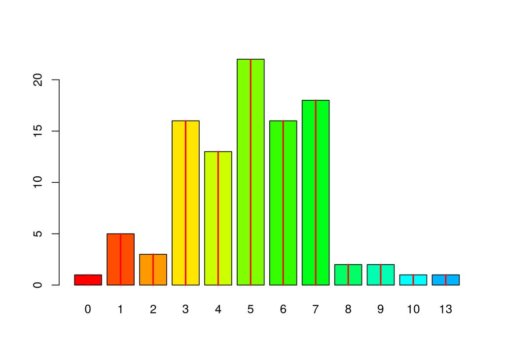

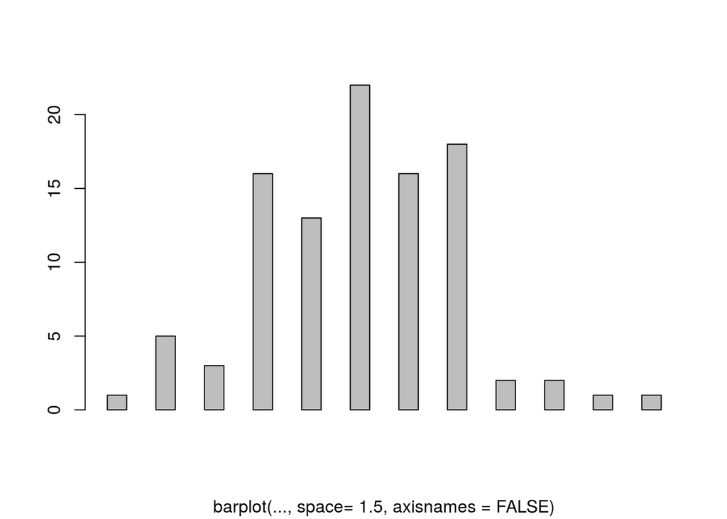

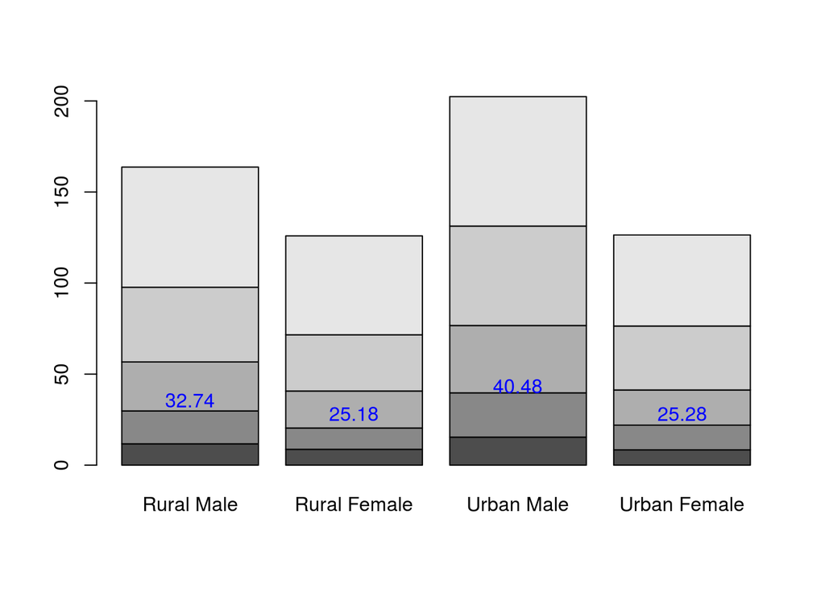

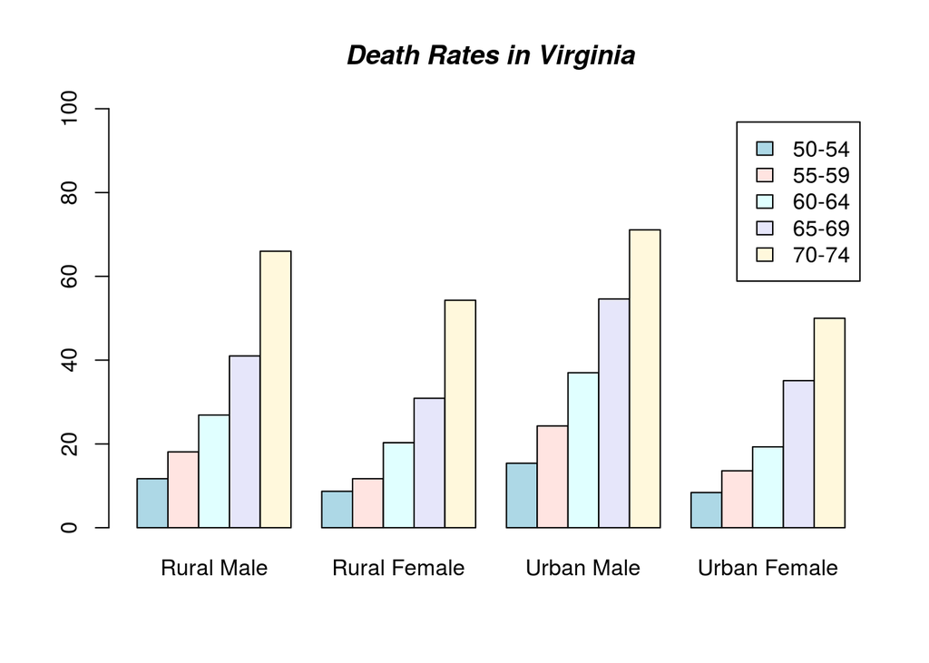

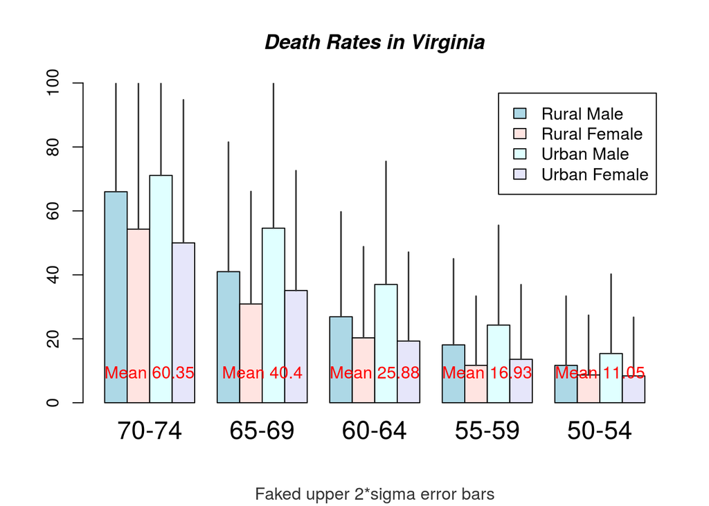

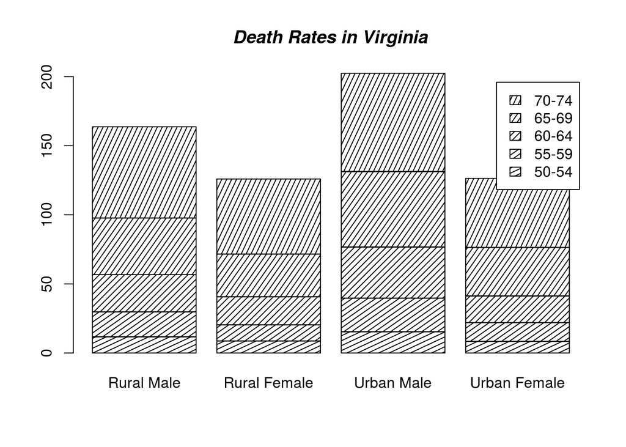

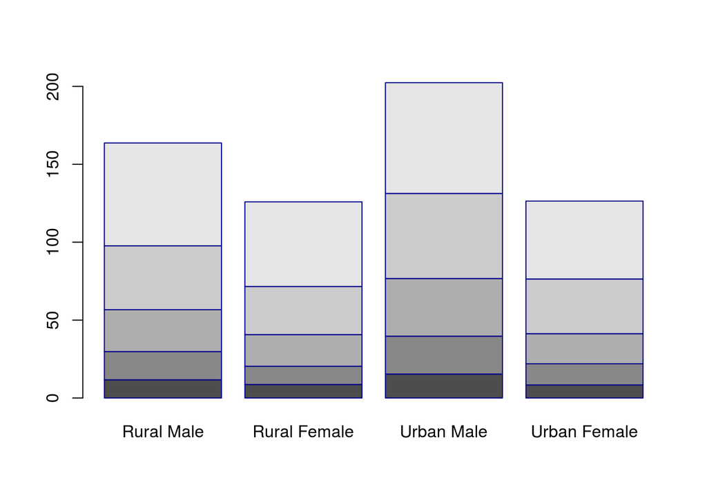

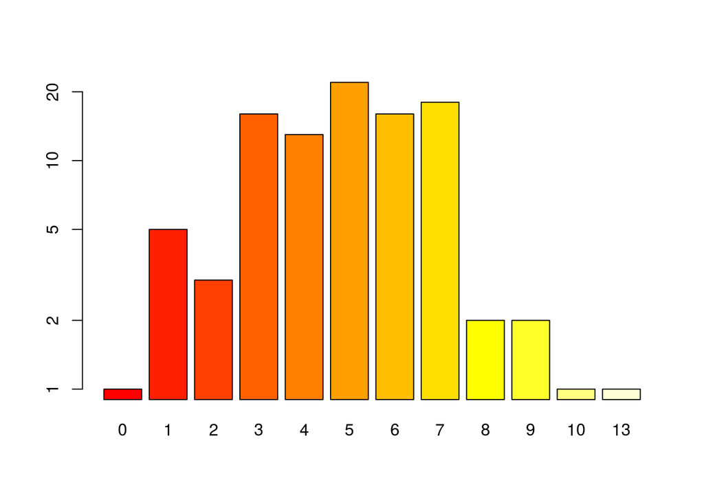

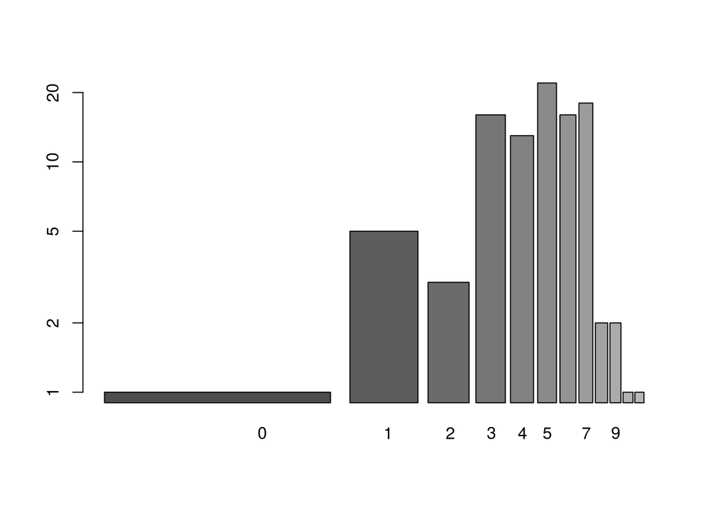

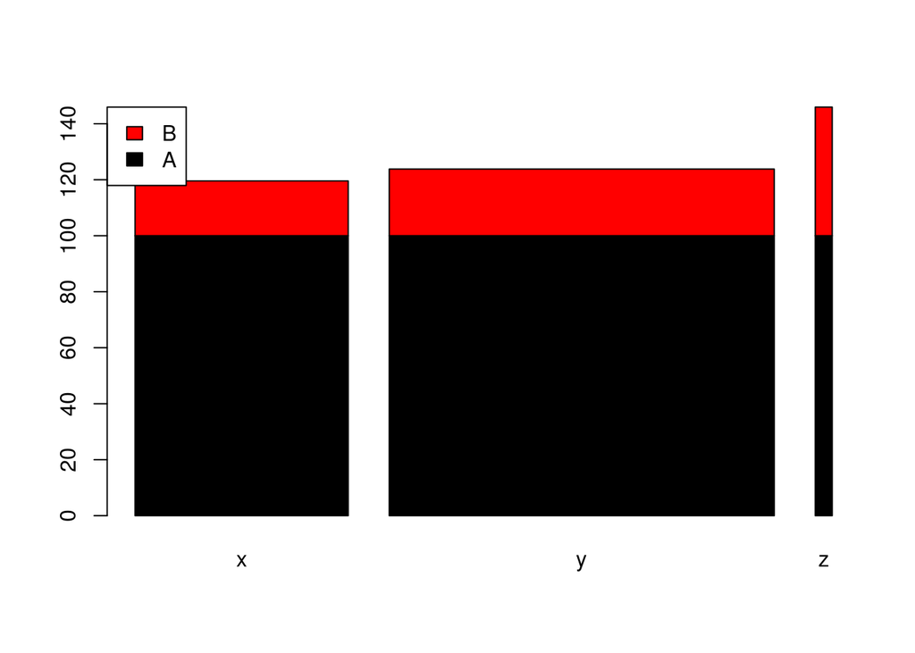

## Histograma

- Se usa para representar las frecuencias de una variable cuantitativa continua.
- Los intervalos del histograma se obtienen con alguno de los criterios mencionados.
- Representación gráfica de la distribución de las observaciones.

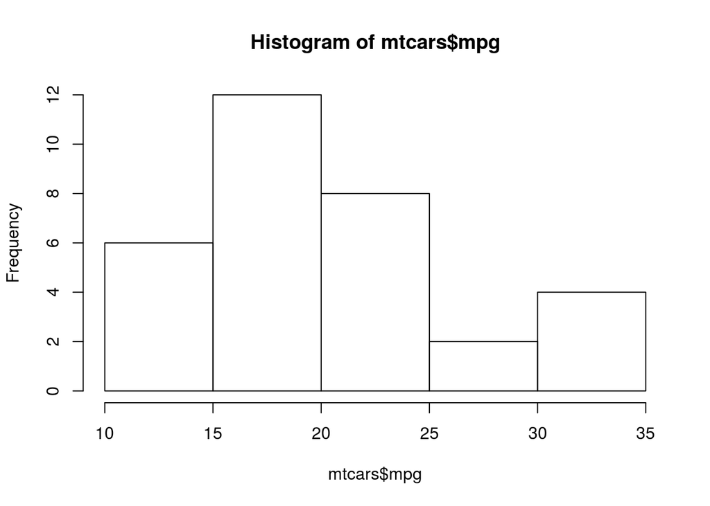

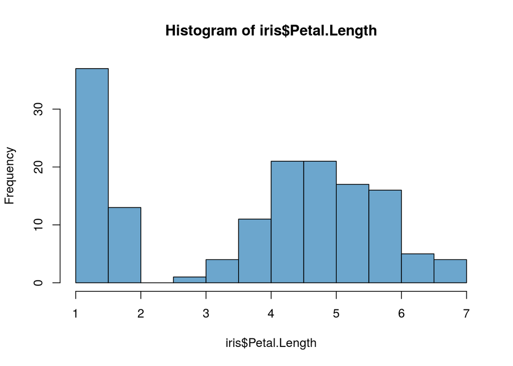

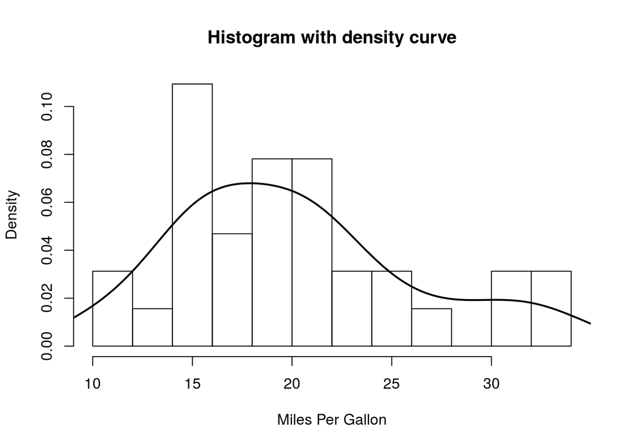

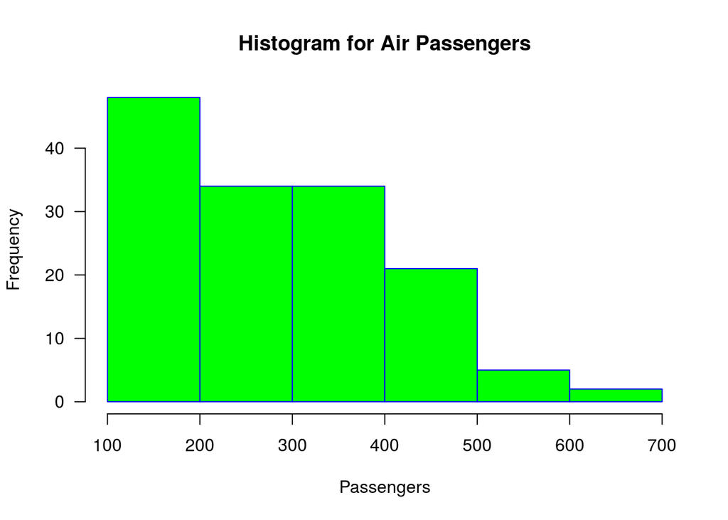

## Diagrama de cajas y bigotes (Boxplot)

- Se usa para variables cuantitativas continuas.
- Se construye utilizando los tres cuartiles, el valor máxio, el valor mínimo y el rango intercuartílico.
- Posibilidad de localizar observaciones extremas o atípicas (outliers).
  - Valor atípico leve $si\ x_{i}<Q1-(1.5*RIQ)\ o\ x_{i}>Q3+(1.5*RIQ)$
  - Valor atípico extremo $si\ x_{i}<Q1-(3*RIQ)\ o\ x_{i}>Q3+(3*RIQ)$$

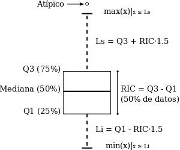

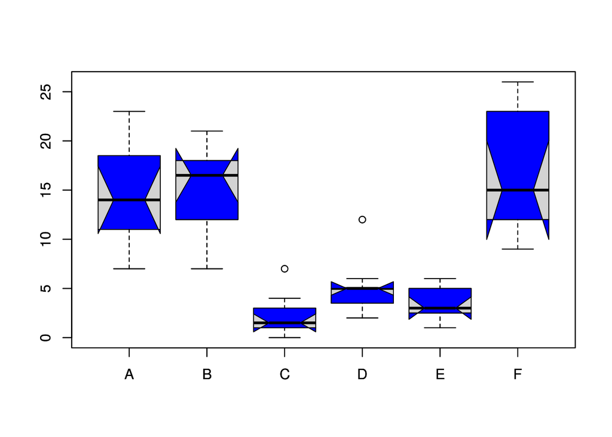

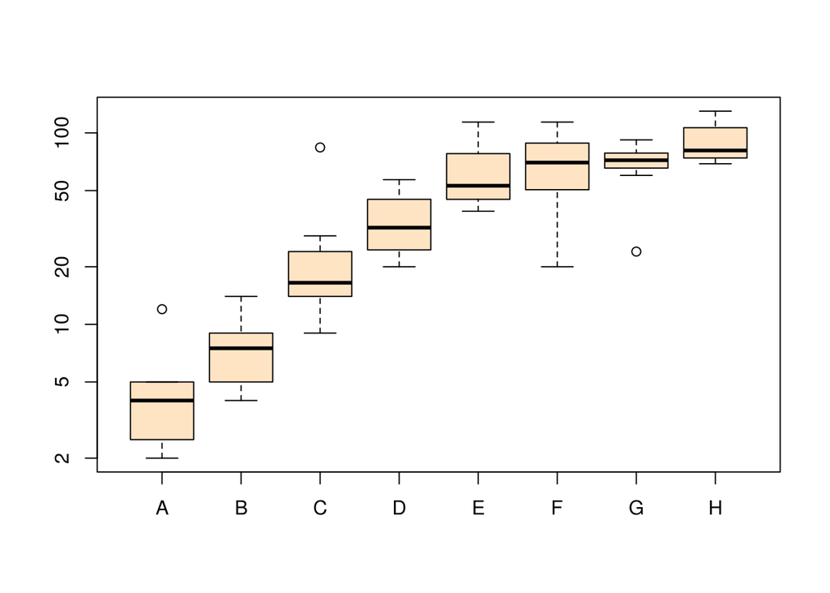

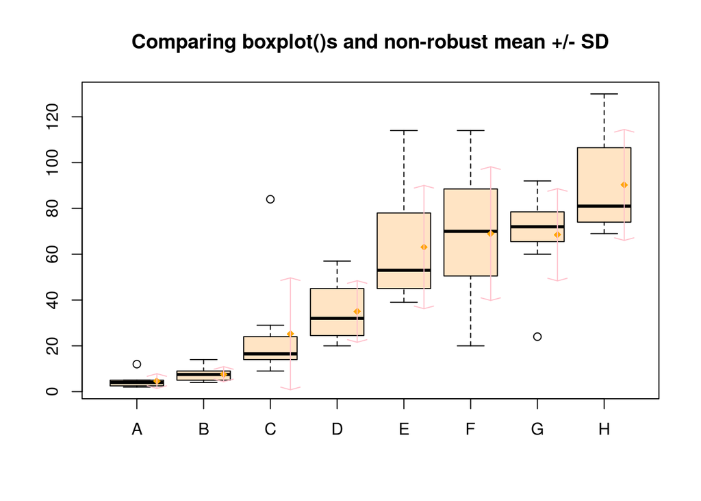

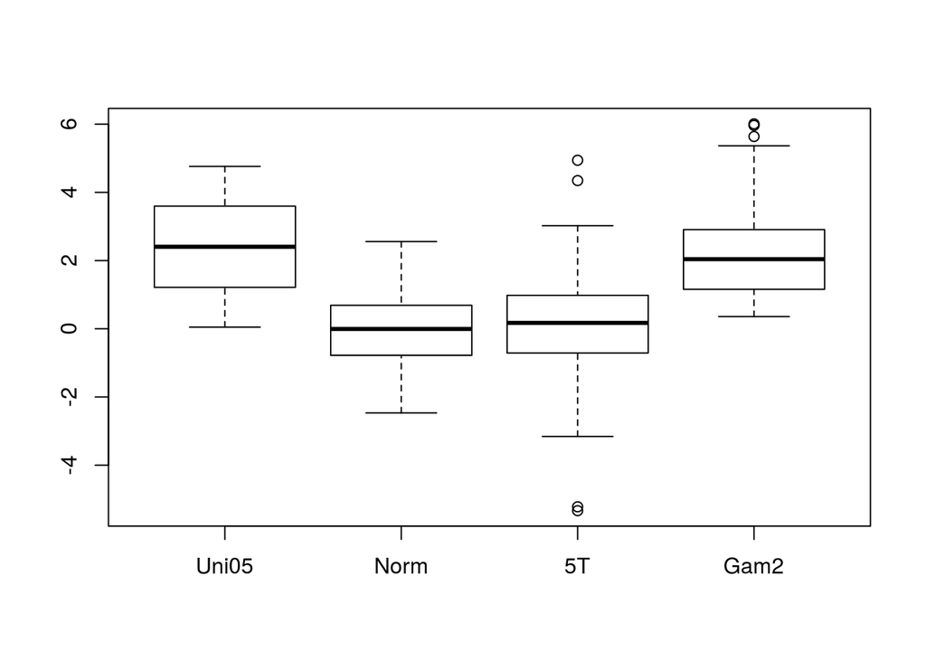

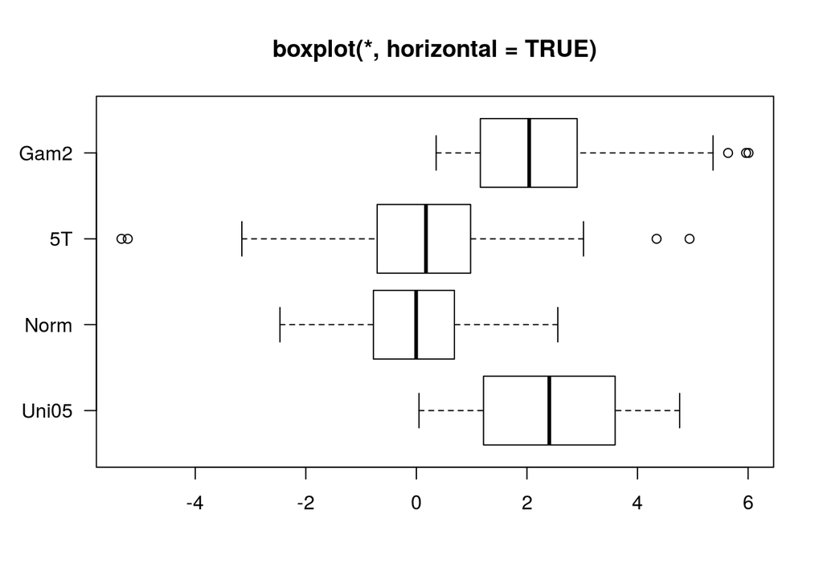

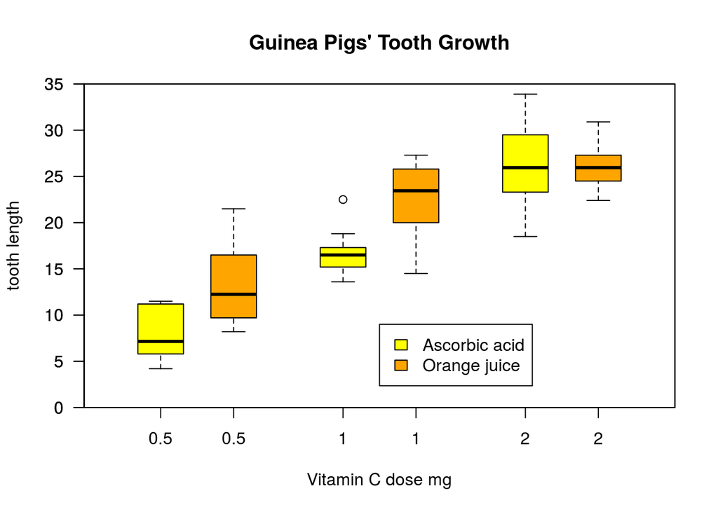

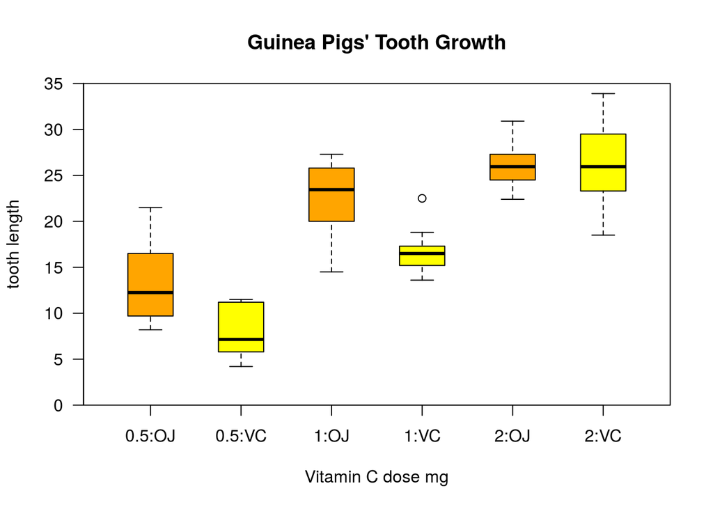

## Diagrama de dispersión

- Representación gráfica de la relación de dos variables.
- Relaciones lineales, exponenciales, sin relación.
- Importante para conocer la variación conjunta de variables.

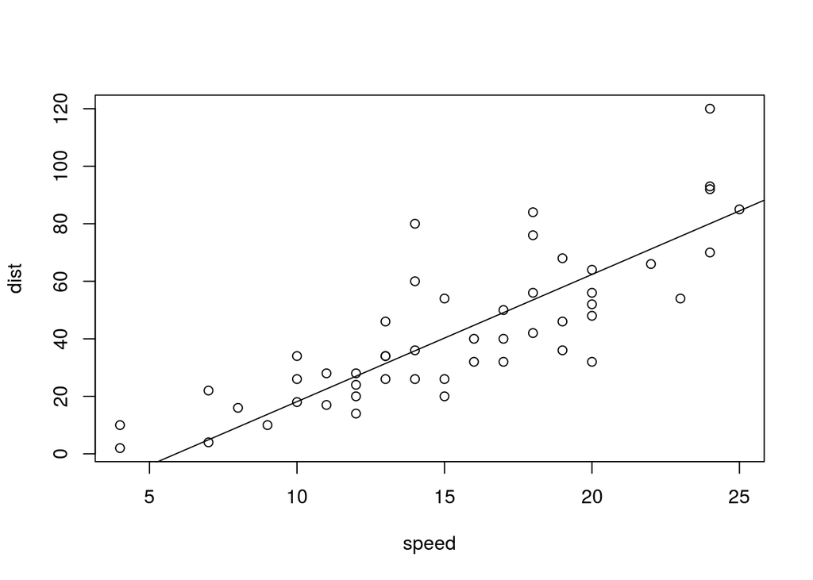

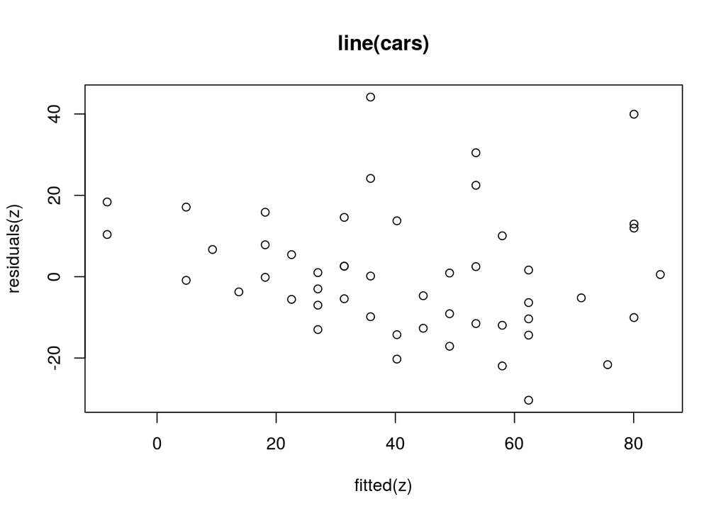

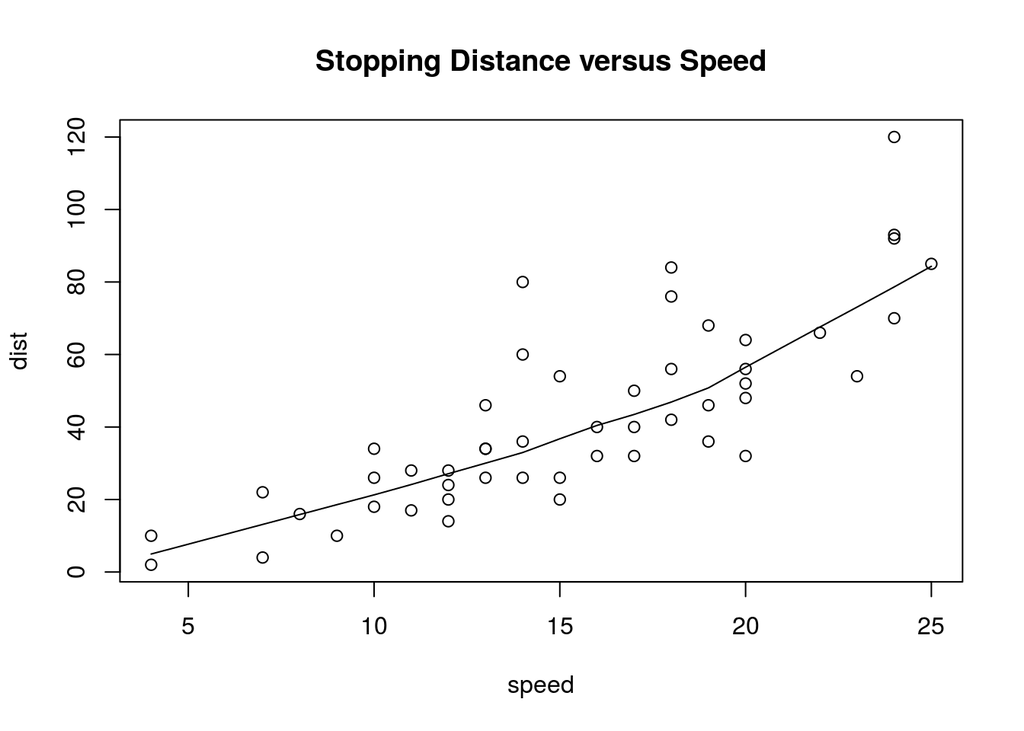

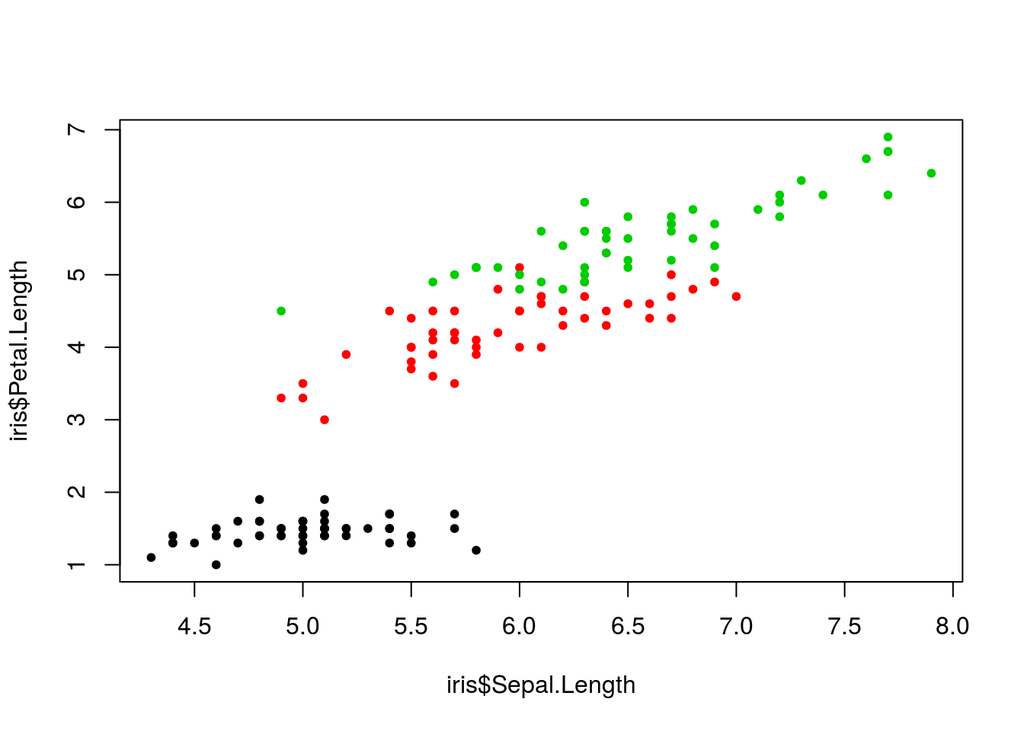

### Matriz de dispersión o correlación

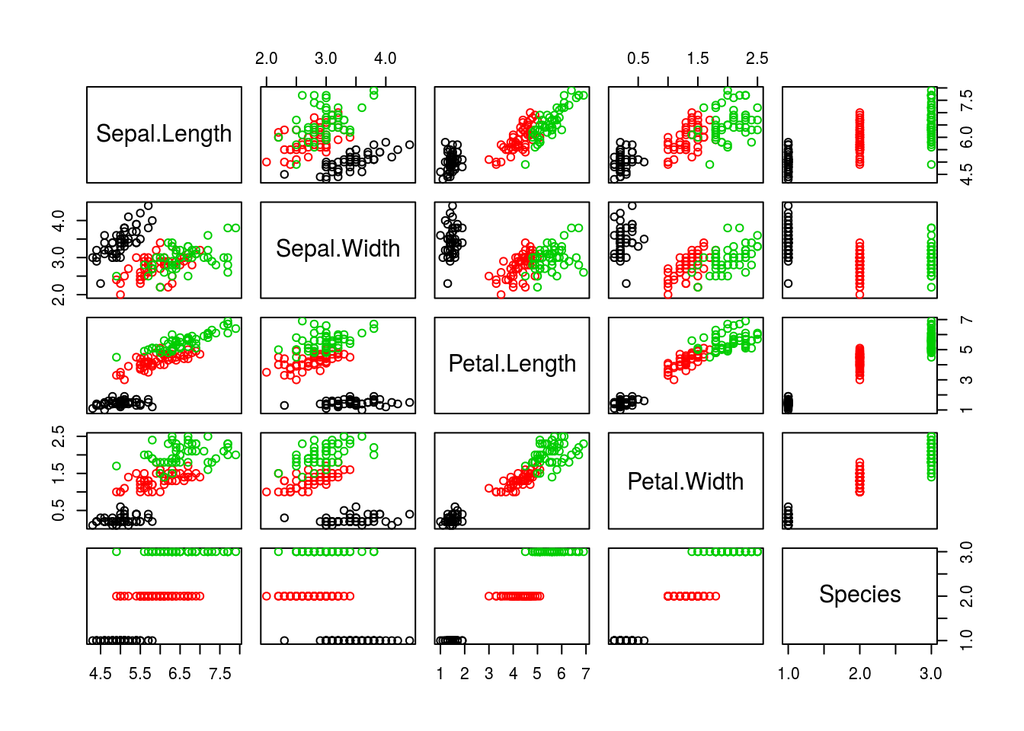